# Manufacturing Defects (28 points)

#### Authors

```python
#import packages here
import numpy as np
import matplotlib.pyplot as plt
import os
import pandas as pd
import cv2
import re
import glob
from scipy.signal import find_peaks
```

#### In previous notebooks you have already explored the importance of manufacturing parameters and curing cycles, specifically the Cure kinetics and Rheokinetics of composite production. The manufacturing process plays a crucial role when we try to guarantee a predictable part quality.

#### In this notebook you will be working on cases for which manufacturing did not reach the expected and predicted quality or, in other words, manufacturing related defects have been detected.

#### Understanding defects is an important part of composite manufacturing. Defects can (and will) occur during most manufacturing processes. You will learn to recognise defects, assess data for components with and without defects, how to deal with shrinkage of polymeric matrices, how to use image analysis to assess defects in fabric weaves, and reflect on the consequences of defects.

#### Defects in composites can be generally classified as one of the types shown in the graph (Figure 1) below.

[figure not shown]

Figure 1

### Question 1 (3 points)

#### A case study will be used in this question to start approaching the problem of defects. In this case you will be considering the implosion of the Titan Submersible. Titan imploded during an expedition to the Titanic in June 2023, killing all five occupants Upon news of the fate of Titan, the company closed its Everett office indefinitely. Soon after the implosion, its subsidiary OceanGate Expeditions also suspended operations. From July 2023, OceanGate's websites defaulted to a message advising: "OceanGate has suspended all exploration and commercial operations."

#### As a first step, please read carefully the article provided with this notebook:

#### Kramer, D., & Otin, S. (2024, July 5). Materials Laboratory Factual Report. National Transportation Safety Board.

#### Question 1.1: Read Section 1.0 of the report on "Composite hull manufacturing and vessel assembly". Identify and describe an ex-ante monitoring process used by OceanGate and specify the defect type.

Answer: The ex-ante monitoring process used by OceanGate during assembly process is the contact-angle measurement during surface preparation, when preparing to bond the composite hull to the CP Grade-3 machined titanium segments. After degreasing with MEK and roughening with stearate-free sandpaper, contatc angle was measured to ensure that the surface was "active" (clean and no contamination). Filtered shop air were used to blow away particulates, which is again tested by contact angle to ensure it did not introduce contamination. This is classified as monitoring as contact angle measurements are used as a metric for the surface cleanliness and surface energy, and this affects whether the adhesive will properly wet and bond to surface. Defect type is classified under "External: Contamination" according to the chart above. Bond interface contamination leads to adhesive bonding defect, cause catastrophic delamination under pressure due to the weak bonds at surface interface.

#### Question 1.2: Propose an in-situ and an ex-post detection method to identify the defect discussed in Q1.1.

Answer: Optical inspection method using UV can be used as an in-situ monitoring method. The key rational here is that it is non-contact and so does not interfere with the process. This works by using a UV camera, with LEDs illuminating the surface and using algorithms for real-time image processing to check if there is any abnormalities. As contamination is detected, the process can be stopped and the surface will be cleaned before proceding again. Ultrasonic NDT can be used as a ex-post detection method. The adhesive joint is scanned to detect debonding, weak bond regions or any irregularities. Contamination often result in poor adhesion that is detectable through scanning, ultrasonic waves penetrate the solid, reflecting off internal boundaries and discontinuities, revealing hidden defects within the adhesive layer. This method is one the moset widely used methods to monitor bonded joints, as it can characterize the bond interface due to its high sensitivity. Therefore, it has reliability in this aspect.

#### Question 1.3: The following images (Figure 2a, 2b, 2c) have been discussed in the report. Classify them as fibre, matrix, process or external defects and discuss possible causes of these defects.

Note: Refer to the original pictures in the report for better quality.

[figure not shown]

Figure 2a

[figure not shown]

Figure 2b

[figure not shown]

Figure 2c

Answer: Figure 2a is a process defect, as can be seen in the porosity and exposed matrix(glossy) regions. Porosity is possibly caused by the trapped air bubbles and insufficient consolidation during the AFP layup process as a result of poor compaction. As stated in the report, OceanGate built the hull by winding the tows onto a carbon steel mandrel by automatic fibre placement. Moreover, another likely cause of the porosity is during the autoclave curing process which was used by OceanGate to construct the hull, there may be insufficient pressure or leaks. Handling damage or usage accumulative damage may have caused an open-up near the surface and expose plies. Figure 2b is a fibre defect, as can be seen in the delamination between layers. This may be caused by the defect mentioned in Question 1.1 due to contamination that results in weak bonding at the co-bond interface, which may be caused by residue, dust etc. The fact that 1-inch layers were co-bonded suggests that interlaminar stresses may also have been amplified more than usual to enhance delamination. Figure 2c is an external defect, as can be seen in the surface waviness, which seem to be out of plane(not in the fibre direction). As stated in the report some plies were laid without tension, which causes tow tension issues in the AFP process, resulting in local buckling and surface waviness as seen here. Repeated cures result in extensive handling which may result in external loading that caused the buckling.

### Question 2 (2 points)

#### Free shrinkage and residual stresses

#### Additional defects that can occur in composites include micro-cracks, typically emerging from the combination of residual stresses with thermal cycling or mechanical loading. The primary cause of residual stresses at a micro-mechanical level is the disparity in shrinkage between the fibers and the matrix. Specifically, the polymer matrix tends to undergo considerably more shrinkage (dictated by the coefficient of thermal expansion, CTE) during consolidation and cooling compared to the contracting fibers.

[figure not shown]

Figure 3

#### In this question we will work towards identifying the differences in shrinkage characteristics of two different thermoplastics (an amorphous and a semi-crystalline polymer). Draw typical storage modulus vs. temperature graphs for both categories. Display them in two different graphs. Explain the evolution of mechanical properties, including: how the storage modulus evolves as a function of temperature. Also identify and explain the differences in relevant temperature points and ranges along the curve - structural range, processing range, free volume evolution, melting and glass transition points between the 2 graphs.

Answer:

As shown in the graph, amorphous thermoplastics do not have a defined melting point. At lower temperatures, they exist in the glassy/structural range: chain segments are frozen and that means low free volume and limited chain mobility. As temperature increases, increases in free volume result in segmental relaxation and a decrease in stiffness, this is reflected by a drop in the storage modulus E' by several orders of magnitude. This transition results in the polymer existing in the rubbery regime. This region, post Tg, is where the polymer can be processed. E' has dropped to a range where welding and forming become possible.

Now looking at the semi-crystalline TP graph, we observe similar behaviour in the lower segment of the temperature range: polymer is in the structural/glassy range, chain segments are frozen, low free volume and limited chain mobility, leading to a higher E'. At a given temperature, Tg, it experiences glass transition, and E' drops. However, it stabilizes before the polymer becomes a full melt, and the polymer exists in the rubbery regime. This behaviour is due to the amorphous component of the polymer; the crystalline regions can still carry load and constrain chain mobility, as they remain crosslinked. As temperature increases further, the free volume increases to a point where polymer crystals finally melt, and thus E' drops sharply. Above Tm, the polymer can be formed and processed.

For amorphous thermoplastics, shrinkage primarily results from thermal contraction. As the material cools through Tg, the coefficient of thermal expansion changes due to a sharp reduction in free volume and molecular mobility, which is reflected in the steep increase in storage modulus on the plot. In semi-crystalline thermoplastics, shrinkage arises from both thermal contraction and crystallization-induced densification; as crystalline regions form during cooling below Tm, the associated increase in density leads to larger net shrinkage. Consequently, semi-crystalline polymers generally exhibit higher shrinkage than amorphous polymers, and when constrained (for instance by fibres), this can result in significant residual stresses.

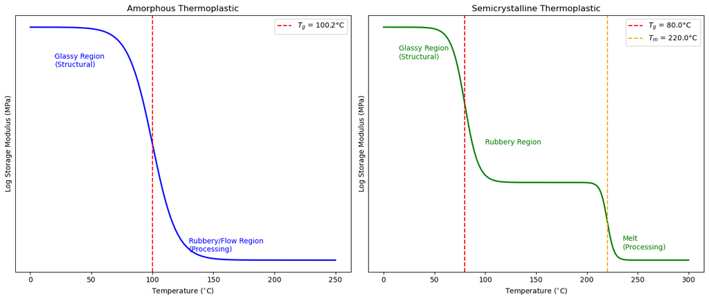

```python
T_amorphous = np.linspace(0, 250, 500)
E_amorphous = 3000 * (1 / (1 + np.exp(0.1 * (T_amorphous - 100)))) + 10
dE_dT_am = np.gradient(E_amorphous, T_amorphous)
Tg_am = T_amorphous[np.argmin(dE_dT_am)]

# semi-crystalline polymer
T_sc = np.linspace(0, 300, 500)
Tg_sc = 80
Tm_sc = 220
def semi_crys_modulus(t):
    val = 3000
    if t > Tg_sc:
        val = 1000
    if t > Tg_sc and t < Tm_sc:
        val = 1000 - 2 * (t - Tg_sc)
    if t >= Tm_sc:
        val = 10
    return val

E_semicrys = []
for t in T_sc:
    term1 = 2000 / (1 + np.exp(0.15 * (t - Tg_sc)))
    term2 = 1000 / (1 + np.exp(0.3 * (t - Tm_sc)))
    E_semicrys.append(term1 + term2 + 10)
E_semicrys = np.array(E_semicrys)

dE_dT_sc = np.gradient(E_semicrys, T_sc)
split_thresh = 0.5 * (Tg_sc + Tm_sc)
mask_tg = T_sc < split_thresh
mask_tm = T_sc >= split_thresh
Tg_sc = T_sc[mask_tg][np.argmin(dE_dT_sc[mask_tg])]
Tm_sc = T_sc[mask_tm][np.argmin(dE_dT_sc[mask_tm])]

fig, (ax1, ax2) = plt.subplots(1, 2, figsize=(14, 6))
ax1.plot(T_amorphous, E_amorphous, 'b-', linewidth=2)
ax1.set_title('Amorphous Thermoplastic')
ax1.set_xlabel('Temperature ($^{\circ}$C)')
ax1.set_ylabel('Log Storage Modulus (MPa)')
ax1.axvline(x=Tg_am, color='r', linestyle='--', label=f'$T_g$ = {Tg_am:.1f}°C')
ax1.text(20, 2500, 'Glassy Region\n(Structural)', fontsize=10, color='blue')
ax1.text(130, 120, 'Rubbery/Flow Region\n(Processing)', fontsize=10, color='blue')
ax1.legend()

ax2.plot(T_sc, E_semicrys, 'g-', linewidth=2)
ax2.set_title('Semicrystalline Thermoplastic')
ax2.set_xlabel('Temperature ($^{\circ}$C)')
ax2.set_ylabel('Log Storage Modulus (MPa)')
ax2.axvline(x=Tg_sc, color='r', linestyle='--', label=f'$T_g$ = {Tg_sc:.1f}°C')
ax2.axvline(x=Tm_sc, color='orange', linestyle='--', label=f'$T_m$ = {Tm_sc:.1f}°C')
ax2.text(15, 2600, 'Glassy Region\n(Structural)', fontsize=10, color='green')
ax2.text(100, 1500, 'Rubbery Region', fontsize=10, color='green')
ax2.text(235, 150, 'Melt\n(Processing)', fontsize=10, color='green')
ax2.legend()


#remove these two lines to add numerical values on y back in:
ax1.set_yticks([])
ax2.set_yticks([])

plt.tight_layout()
plt.show()
```

### Question 3 (4 points)

#### When dealing with TP consolidation cycles, understanding shrinkage and the potential occurrence of residual stresses in a part is crucial when dealing with the design of consolidation cycles for thermoplastic composites.

#### For the production and autoclave consolidation of a 1 m wide and 2 m long panel using a single unidirectional lamina, two carbon fibre thermoplastic prepregs are under consideration: one with a Polycarbonate matrix and the other with a Polyamide matrix, both utilizing T1000 UD as the reinforcement. It concerns a zero-bleed prepreg with a fibre volume fraction of 55%. The consolidation cycle involves a 200°C dwell, maintained for 1 hour, followed by a cooling phase at 2°C/min until reaching room temperature (20°C). The consolidation cycle is shown in Figure 4 (the heating phase is not shown, as it is not relevant for this question). Equations and assumption that will help you answer the questions, are given below.

#### The longitudinal coefficient of linear thermal expansion for a composite ply can be calculated/estimated as follows:

$$\alpha_{l} = \frac{(1-\nu_{f})E_{r}\alpha_{r}+ \nu_{f}E_{lf} \alpha_{lf}}{(1-\nu_{f})E_{r} +\nu_{f}E_{lf}}$$

#### The transverse coefficient of linear thermal expansion for a composite ply can be calculated/estimated as follows:

$$\alpha_{t} = (1-\nu_{f})\alpha_{r}+ \nu_{f}\alpha_{tf} +(1-\nu_{f})\alpha_{r}\nu_{r} +\nu_{12f}\alpha_{lf}\nu_{f} -\nu_{12}\alpha_{l}$$

#### Where $\nu_{f}$ represents fibre volume content, $E_{r}$ [GPa] Young's modulus of the matrix, $\nu_{r}$ the Poisson ratio of the matrix, $\alpha_{r}$ [1/°C] coefficient of linear thermal expansion of the matrix, $\alpha_{lf}$ [1/°C] and $\alpha_{tf}$ [1/°C] thermal expansion coefficients (CLTE) of fibres in the longitudinal and transverse direction, $E_{lf}$ [GPa] the longitudinal Young's modulus of the fibres, $\nu_{12}$ the in-plane Poisson ratio of the lamina and $\nu_{12f}$ Poisson’s ratio of the fibres.

#### The thermal strain (in longitudinal and transverse direction) can be calculated as follows:

#### $$\epsilon = \int_{0}^{t} \alpha(t)\Delta Tdt$$

| Matrix | Young's modulus [GPa] | Poisson ratio | CLTE [1/°C] |
| --- | --- | --- | --- |
| Polycarbonate | 1.4 | 0.37 | $70.2 \cdot 10^{-6}$ |
| Polyamide 6 | 3 | 0.39 | $85 \cdot 10^{-6}$ |

[figure not shown]

Figure 4

[figure not shown]

Figure 1

#### The following assumptions are made:

#### - The lamina undergoes free shrinkage

#### - The properties of the resin and fibers, including volume fraction (vf), Poisson's ratio, and coefficient of linear thermal expansion (CLTE), are non-temperature dependent.

#### - Poisson ratio of the lamina can be derived using the rule of mixtures

#### Question 3.1: Given the provided equations, material properties, consolidation cycle, and the listed assumptions, please calculate:

#### - the composite material's linear coefficient of thermal expansion (in longitudinal and transverse direction).

#### - the expected strain after reaching room temperature in both length and width direction of the panel

#### - the percentage of shrinkage in length and width direction of the panel

#### Note - You may use Kulkarni R, Ochoa O. Transverse and Longitudinal CTE Measurements of Carbon Fibers and their Impact on Interfacial Residual Stresses in Composites. Journal of Composite Materials. 2006;40(8):733-754. doi:10.1177/0021998305055545 as reference for material data.

```python
vf = 0.55
L = 2.0  # fibre direction
W = 1.0
time_total = 90*60

T_dwell = 200.0
T_room  = 20.0
dT = T_room - T_dwell

E_lf = 294.0   # GPa
alpha_lf = -1.4e-6  #values from doi:10.1177/0021998305055545
alpha_tf =  3.8e-6  #values from doi:10.1177/0021998305055545
nu_12f = 0.3       # fibre Poisson ratio for UD from https://www.performance-composites.com/carbonfibre/mechanicalproperties_2.asp

matrices = {
    "Polycarbonate": {"E_r": 1.4, "nu_r": 0.37, "alpha_r": 70.2e-6},
    "Polyamide 6":   {"E_r": 3.0, "nu_r": 0.39, "alpha_r": 85.0e-6},
}

def nu12_rule_of_mixtures(vf, nu12f, nu_r):
    #Assumption:lamina Poisson ratio from rule of mixtures
    return vf * nu12f + (1 - vf) * nu_r

def alpha_longitudinal(vf, E_r, alpha_r, E_lf, alpha_lf):
    num = (1 - vf) * E_r * alpha_r + vf * E_lf * alpha_lf
    den = (1 - vf) * E_r + vf * E_lf
    return num / den

def alpha_transverse(vf, alpha_r, alpha_tf, nu_r, nu12f, alpha_lf, nu12, alpha_l):
    return ((1 - vf) * alpha_r
            + vf * alpha_tf
            + (1 - vf) * alpha_r * nu_r
            + nu12f * alpha_lf * vf
            - nu12 * alpha_l)  # 1/C

rows = []
alphal_lst = []
alphat_lst = []
materials_order = []
for name, props in matrices.items():
    E_r = props["E_r"]         # GPa
    nu_r = props["nu_r"]
    alpha_r = props["alpha_r"] # 1/C

    nu12 = nu12_rule_of_mixtures(vf, nu_12f, nu_r)

    a_l = alpha_longitudinal(vf, E_r, alpha_r, E_lf, alpha_lf)
    a_t = alpha_transverse(vf, alpha_r, alpha_tf, nu_r, nu_12f, alpha_lf, nu12, a_l)

    alphal_lst.append(a_l)
    alphat_lst.append(a_t)
    materials_order.append(name)

    eps_l = a_l * dT
    eps_t = a_t * dT

    shrink_l_pct = 100.0 * eps_l
    shrink_t_pct = 100.0 * eps_t

    dL = eps_l * L
    dW = eps_t * W

    rows.append({"Matrix": name,"alpha_l (1/C)": a_l,"alpha_t (1/C)": a_t,"eps_l": eps_l,"eps_t": eps_t,"shrink_l (%)": shrink_l_pct,"shrink_t (%)": shrink_t_pct,"deltaL (m)": dL,"deltaW (m)": dW,})

df = pd.DataFrame(rows)
pd.set_option("display.float_format", lambda x: f"{x:.6e}")
print("Cooling deltaT =", dT, "Celsius\n")
print(df)
```

```
Cooling deltaT = -180.0 Celsius

          Matrix  alpha_l (1/C)  alpha_t (1/C)        eps_l         eps_t  \
0  Polycarbonate  -1.122122e-06   4.550928e-05 2.019819e-04 -8.191671e-03
1    Polyamide 6  -6.846366e-07   5.525962e-05 1.232346e-04 -9.946731e-03

   shrink_l (%)  shrink_t (%)   deltaL (m)    deltaW (m)
0  2.019819e-02 -8.191671e-01 4.039638e-04 -8.191671e-03
1  1.232346e-02 -9.946731e-01 2.464692e-04 -9.946731e-03
```

Answers:

| Matrix | α_l (1/°C) | α_t (1/°C) | ε_l (–) | ε_t (–) | Shrinkage_l | Shrinkage_t | ΔL (m) | ΔW (m) |
| --- | --- | --- | --- | --- | --- | --- | --- | --- |
| Polycarbonate | -1.122122e-06 | 4.550928e-05 | 2.019819e-04 | -8.191671e-03 | 2.019819e-02 | -8.191671e-01 | 4.039638e-04 | -8.191671e-03 |
| Polyamide 6 | -6.846366e-07 | 5.525962e-05 | 1.232346e-04 | -9.946731e-03 | 1.232346e-02 | -9.946731e-01 | 2.464692e-04 | -9.946731e-03 |

#### Question 3.2: Provide insights on the outcomes of question 3.1 from:

#### - a composites standpoint: this should encompass expectations regarding the direction of highest strain or shrinkage, considerations about the acceptability of dimensional changes, and whether adjustments in the design would be necessary to accommodate these variations.

#### - a matrix point of view: Offer commentary on the differences between the two thermoplastic resin materials (Polycarbonate and Polyamide), elucidating the reasons behind these differences in terms of their chemical composition, molecular structure, and thermal behaviors and which matrix option you would consider yielding the best mechanical properties or dimensional stability.

From a matrix point of view, there are aromatic rings in polycarbonate while polyamide 6 is a long molecular chain. Semicrystalline polymers undergo an additional shrinkage that occurs due to the formation of the crystalline phase. Depending on the polymer type and cooling rate, the crystallization shrinkage can be an order of magnitude higher than the thermal shrinkage. Also, the crystallization shrinkage increases with increasing degree of crystallinity. Thus, polycarbonate is more amorphous as a polymer and tend to have a more predictable thermal contraction due to no crystallisation. Polyamide 6 is semi-crystalline thermoplastic polymer and when cooled down, will develop crystallinity and increase density and decrease free volume. There is also polar amide groups and hydrogen bonding present here, so there is a level of toughness, but more sensitive to free volume decrease due to crystallinity (around 35-45 wt.%) which results in greater scatter in shrinkage, as crystalline regions more densely packed than amorphous ones. Therefore, if dimensional stability is prioritised, choose polycarbonate as it has lower transverse shrinkage and no crystallisation-driven shrinkage. If mechanical performance such as stiffness is prioritised, choose polyamide 6 as it has higher toughness, but expect larger and more scatter in shrinkage.

### Question 4 (2 points)

#### Residual stresses may emerge during composite manufacturing due to differential strains between the composite part and the tooling as seen in Fig. 5. This issue arises from the coefficient of thermal expansion (CTE) mismatch between the part and the mould/tooling. Residual stresses may potentially lead to lower load carrying capabilities, cracks and areas with resin-rich or resin-starved characteristics if not appropriately addressed.

#### In the previous question, we assumed free shrinkage of the part. When shrinkage of a composite part during manufacturing is constrained by a material (with a different CTE), this shrinkage can be transformed into stress.

#### To effectively design a mold for the panel considered in question 3, three potential materials are under consideration: Aluminum 6061-T6, Invar 36, and CFRP composite. It is assumed that the mold is uniformly heated and monolithic throughout the process.

#### Find the coefficients of thermal expansion for this three possible mould materials (refer to online material databases like MatWeb) and discuss which one will be the most suitable option for the Polycarbonate and Polyamide CF reinforced parts from question 3.

#### Consider the following for the CFRP mold AND laminate -

#### 1. Both mold and laminate are quasi-isotropic (QI) $[0^\circ, -45^\circ, 45^\circ, 90^\circ]_s$.

#### 2. Calculate CTE of the QI composites using the modified CLT equations given in Velea, M. N., & Lache, S. (2015). Thermal expansion of composite laminates. Bulletin of the Transilvania University of Brasov. Series I-Engineering Sciences, 25-30.

#### 3. To simplify the calculations for QI stacking -

$$ V_{1A} = V_{2A} = V_{3A} = V_{4A} = 0$$

$$ A_{16} = A_{26} = 0$$

$$ A_{11} = A_{22}$$

#### 4. $E_1$ = 142000MPa; $E_2$ = 11200MPa; $\nu_{12}$ = $\nu_{21}$ = 0.3; $G_{12}$ = 5000MPa; t = 0.125mm

#### You may also refer to this article: Zobeiry N, Park J, Poursartip A. An infrared thermography-based method for the evaluation of the thermal response of tooling for composites manufacturing. Journal of Composite Materials. 2019;53(10):1277-1290.

[figure not shown]

Figure 5: distortion due to shear interaction at tool interface

```python
E1 = 142000e6    # Pa
E2 = 11200e6     # Pa
nu12 = 0.3
nu21 = 0.3
G12 = 5000e6     # Pa
t = 0.125e-3     # m (ply thickness)

denom = (1 - nu12 * nu21)
Q11 = E1 / denom
Q22 = E2 / denom
Q12 = (nu12 * E2) / denom
Q66 = G12

U1 = (3*Q11 + 3*Q22 + 2*Q12 + 4*Q66) / 8
U2 = (Q11 - Q22) / 2
U3 = (Q11 + Q22 - 2*Q12 - 4*Q66) / 8
U4 = (Q11 + Q22 + 6*Q12 - 4*Q66) / 8
U5 = (Q11 + Q22 - 2*Q12 + 4*Q66) / 8

V0A = t
V1A = V2A = V3A = V4A = 0

A11 = U1*V0A + U2*V1A + U3*V3A
A12 = U4*V0A - U3*V3A
A66 = U5*V0A - U3*V3A
A22 = A11
A16 = A26 = 0

A_mat = np.array([[A11, A12, A16],
                  [A12, A22, A26],
                  [A16, A26, A66]])

def calculate_laminate_cte(A, U1, U2, U3, U4, U5, V0A, V1A, V2A, alpha_1, alpha_2):
    K1 = (U1 + U4)*(alpha_1 + alpha_2) + U2*(alpha_1 - alpha_2)
    K2 = U2*(alpha_1 + alpha_2) + (U1 + 2*U3 - U4)*(alpha_1 - alpha_2)
    K3 = U2*(alpha_1 + alpha_2) + 2*(U3 + U5)*(alpha_1 - alpha_2)

    A_inv = np.linalg.inv(A)
    force_vector = np.array([[K1*V0A + K2*V1A],
                             [K1*V0A - K2*V1A],
                             [K3*V2A]])
    alpha_matrix = 0.5 * A_inv @ force_vector
    return alpha_matrix

print(f"{'Material':<15} | {'alpha_l (1/°C)':<20} | {'alpha_t (1/°C)':<20}")
for name, a1, a2 in zip(materials_order, alphal_lst, alphat_lst):
    result = calculate_laminate_cte(A_mat, U1, U2, U3, U4, U5, V0A, V1A, V2A, a1, a2)
    ax = result[0][0]
    ay = result[1][0]
    print(f"{name:<15} | {ax:<20.4e} | {ay:<20.4e}")
```

```
Material        | alpha_l (1/°C)       | alpha_t (1/°C)
Polycarbonate   | 3.1235e-06           | 3.1235e-06
Polyamide 6     | 4.4088e-06           | 4.4088e-06
```

| Material | CTE, α_l (1/°C) | CTE, α_l (1/°C) |
| --- | --- | --- |
| Polycarbonate | 3.12e-06 | 3.12e-06 |
| Polyamide 6 | 4.41e-06 | 4.41e-06 |
| Aluminum 6061-T6 | 25.2e-06 | 25.2e-06 |
| Invar 36 | 1.0e-06 | 1.0e-06 |
| CFRP (T-300) | 0.56e-06 | 2.04e-06 |

[output not shown]

## Voids

#### Voids, one of the most extensively examined categories of manufacturing defects, frequently arise during the fabrication of fibre-reinforced composites. Given their significant impact on the physical and thermomechanical properties of the laminates, they have been subject to thorough investigation. In this notebook the following aspects will be taken into consideration: : the origin of voids, the quantification of voids through image analysis and the implications on the mechanical performance of the composite structure.

#### The graph shown below in Figure 6 (from Processing of Polymer Matrix Composites, P.K. Mallick) shows the correlation between shear strength, void content and autoclave cure cycle. The quality of advanced composites and their mechanical properties are strongly influenced by the void volume content. Therefore, solid knowledge on pressure, flow, temperature and material behaviour is required to properly design manufacturing processes.

[figure not shown]

Figure 6: Effect of void volume fraction on the interlaminar shear strength of a composite laminate

### Question 5 (5 points)

[figure not shown]

Figure 7- Void content versus capillary number

#### Use the concept of capillary number (exemplified in Figure 7 above) to explain the physical difference between capillary flow and viscous flow in a fibrous medium. Comment on the balance needed between capillary number, processing window and void content during manufacturing.

#### The flow properties influence the final mechanical part properties. How? Include in your answer which kind of flow would be preferred and which type of defects would occur (and where in your fibrous medium).

Answer: The capillary number is a dimensionless quantity that represents the ratio of viscous forces to capillary forces acting on a fluid moving through a porous medium. It helps distinguish between two dominant flow regimes. The first one is capillary flow, which is dominated by surface tension forces. This results in a spontaneous flow which is driven by wetting behaviour between resin and fibres. It is crucial for impregnating the tight spaces inside the fibre tows (intra-tow). The second regime is viscous flow, which is dominated by the applied pressure gradient pushing the resin. This flow is driven by external pressure (for example autoclave or injection pressure). It moves resin rapidly through the larger open spaces between the fibre bundles (inter-tow) but may bypass the tight spaces inside the bundles if the velocity is too high. In terms of balance, minimising voids requires finding the optimal processing window where a specific range of capillary number is suitable. Too high Ca will result in viscous dominated flow, if the resin flows too fast due high pressure or velocity, the viscous flow covers quickly through the inter-tow spaces, trapping air inside the fibre bundles resulting in voids. The resin moves faster than capillary action can wick it into the tows. Too low Ca will result in capillary dominated flow, where if resin flows too slowly due to low pressure, the capillary forces may wick resin into the tows ahead of the bulk flow, trapping air in the spaces between the bundles (inter-tow voids). Additionally, if the flow is too slow, the resin may cure (gel) before fully filling the mold. The processing window in Figure 7 shows the ideal range where both forces are balanced, minimising the amount of voids formed. As seen in Figure 6, there is a inversely proportional relationship between the interlaminar shear strength and void content. This is because voids act as stress concentrators where cracks initiate, leading to premature failure under loading. Therefore, a balanced flow is preferred also in the mechanical sense(within range), which ensures that micro and macro flows between and inside tows are at compatible speed, to allow air to be evacuated instead of entrapped. Intra-tow voids occur inside fibre bundles, caused by high Ca viscous flow where resin surrounds the tow before penetrating it. Inter-tow voids occur in resin rich areas isntead, in between fibre bundles, caused by low Ca capillary flow.

### Question 6 (8 points)

#### Image analysis is useful when dealing with woven or non-crimp fabric used in advanced composites, particularly for fiber volume content calculations, identifying waviness, and detecting defects. It also plays a crucial role in quality assurance by identifying and characterizing defects such as voids, wrinkles, and variations in resin distribution of the composite products. These defects can substantially affect the structural integrity of the final composite product.

#### Image analysis techniques also add a quantitative dimension to defect assessment, offering measurements of defect size, shape, and distribution. This quantitative data is invaluable for optimising manufacturing processes and upholding stringent quality control standards.

#### A top view (2D) picture has been extracted from a 3D image of a woven fabric laminate and reported below.

#### The darker regions in the image can be identified as voids. Given the critical requirement for aerospace structures to maintain an acceptable volumetric void content of less than 2%, it becomes crucial to quantify void content rather than relying on qualitative observations of the image.

#### For the next few sub-questions, the following keywords can be kept in mind to better answer the questions: Image Opening and Closing, Erosion, Dilation, Filtering, Denoising and Sum of 2 Gaussian Distributions.

#### Question 6.1: Write a script to calculate the void content of the image provided. Then, comment on whether this percentage is acceptable or not.

[figure not shown]

Figure 8

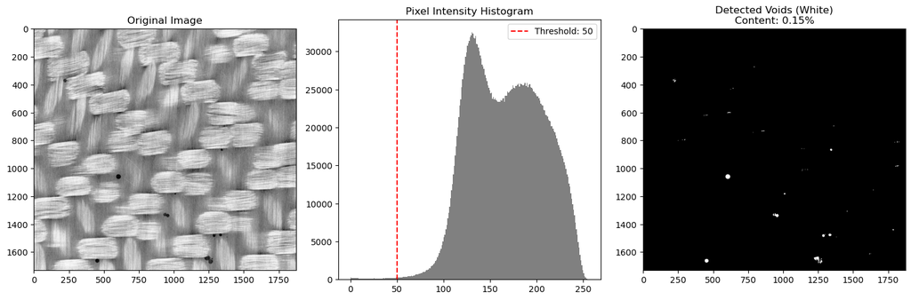

```
Calculated Void Content: 0.15%
ACCEPTABLE (<2%)
```

```python
def calculate_void_content(image_path):
    img = cv2.imread(image_path, 0)
    # filter using Gaussian blur
    img_blurred = cv2.GaussianBlur(img, (5, 5), 0)

    # Manual Threshold method
    manual_threshold_value = 50 #for pixel darker than 50 as 0 is black 255 is white
    _, mask = cv2.threshold(img_blurred, manual_threshold_value, 255, cv2.THRESH_BINARY_INV)

    kernel = np.ones((3,3), np.uint8)

    mask_open = cv2.morphologyEx(mask, cv2.MORPH_OPEN, kernel)

    mask_cleaned = cv2.morphologyEx(mask_open, cv2.MORPH_CLOSE, kernel)

    total_pixels = mask_cleaned.size
    void_pixels = np.count_nonzero(mask_cleaned)
    void_percentage = (void_pixels / total_pixels) * 100

    fig, ax = plt.subplots(1, 3, figsize=(15, 5))
    ax[0].imshow(img, cmap='gray')
    ax[0].set_title('Original Image')
    # Histogram - sum of 2 Gaussians
    ax[1].hist(img.ravel(), 256, [0, 256], color='gray')
    ax[1].axvline(manual_threshold_value, color='r', linestyle='--', label=f'Threshold: {manual_threshold_value}')
    ax[1].set_title('Pixel Intensity Histogram')
    ax[1].legend()
    ax[2].imshow(mask_cleaned, cmap='gray')
    ax[2].set_title(f'Detected Voids (White)\nContent: {void_percentage:.2f}%')
    plt.tight_layout()
    plt.show()

    print(f"Calculated Void Content: {void_percentage:.2f}%")
    if void_percentage < 2.0:
        print("ACCEPTABLE (<2%)")
    else:
        print("UNACCEPTABLE (>2%).")

if __name__ == "__main__":
    calculate_void_content('C:\\Users\\User\\OneDrive - Delft University of Technology\\Master Y1\\Polymer Composite Manufacturing\\Notebook 4 git\\PCM-notebooks\\slice_0130.jpeg')
```

Comment: The percentage of the void content is 0.15% which is acceptable according to the evaluation metric stated above. The part would likely not be rejected in an aerospace context due to the knock-down effect on interlaminar shear strength and compressive properties which would be the case for a defective sample.

#### Question 6.2: Now expand your previous code and apply the same technique to estimate the overall void volume content (in 3D) of the laminate. The folder provided with this notebook contains 107 slices obtained with microtomography. Using your algorithm from question 6.1 calculate the void content of each slice and report all the values in a single graph as a function of the slice number. Finally, calculate the average void content (in 3D) and comment on the difference/similarity with your answer in question 6.1.

#### Please also comment on the applicability of 2D void content measurements to represent the overall void content of a product.

```
Slices processed: 107
Average 3D void volume fraction: 0.1775 %
Slice-to-slice variation: std=0.0055 %, min=0.1653 %, max=0.1878 %
```

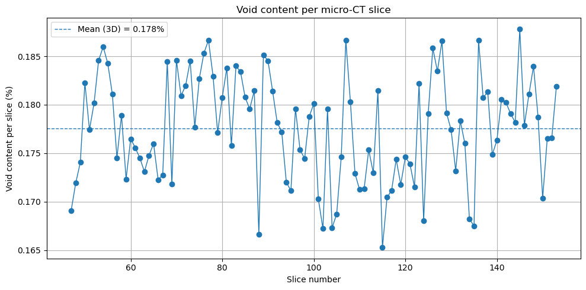

```python
SLICE_DIR = r"C:\Users\User\Downloads\Slices PCM Notebook Defects 2023-2024\Slices PCM Notebook Defects 2023-2024\Slices"
PATTERN = "slice_*.jpeg"

KERNEL_RADIUS = 25              # size of small dark voids
TOP_Q = 0.998
MIN_AREA_PX = 30                #remove blobs smaller

def extract_slice_number(fname: str) -> int:
    m = re.search(r"slice_(\d+)", os.path.basename(fname))
    return int(m.group(1)) if m else 0

def segment_voids_blackhat(gray_u8: np.ndarray,
                           kernel_radius=25,
                           top_q=0.998,
                           min_area_px=30) -> np.ndarray:
    if gray_u8.dtype != np.uint8:
        gray_u8 = gray_u8.astype(np.uint8)

    #Denoise
    gray_blur = cv2.medianBlur(gray_u8, 5)

    # Black-hat filter
    ksize = 2 * kernel_radius + 1
    kernel = cv2.getStructuringElement(cv2.MORPH_ELLIPSE, (ksize, ksize))
    bh = cv2.morphologyEx(gray_blur, cv2.MORPH_BLACKHAT, kernel)

    bh_f = bh.astype(np.float32)
    bh_n = (bh_f - bh_f.min()) / (bh_f.max() - bh_f.min() + 1e-9)

    thr = np.quantile(bh_n, top_q)
    mask = (bh_n > thr).astype(np.uint8)

    # Remove tiny blobs using connected components
    num, labels, stats, _ = cv2.connectedComponentsWithStats(mask, connectivity=8)
    cleaned = np.zeros_like(mask)
    for i in range(1, num):
        area = stats[i, cv2.CC_STAT_AREA]
        if area >= min_area_px:
            cleaned[labels == i] = 1

    return cleaned.astype(bool)

files = glob.glob(os.path.join(SLICE_DIR, PATTERN))
files.sort(key=extract_slice_number)
results = []
for f in files:
    gray = cv2.imread(f, cv2.IMREAD_GRAYSCALE)
    if gray is None:
        print(f"Warning: could not read {f}, skipping.")
        continue

    void_mask = segment_voids_blackhat(
        gray,
        kernel_radius=KERNEL_RADIUS,
        top_q=TOP_Q,
        min_area_px=MIN_AREA_PX
    )

    void_area_frac = void_mask.mean()          # 2D area fraction on that slice
    void_percent = 100.0 * void_area_frac

    results.append({
        "slice": extract_slice_number(f),
        "void_area_fraction": void_area_frac,
        "void_percent": void_percent,
        "file": os.path.basename(f)
    })

df = pd.DataFrame(results).sort_values("slice").reset_index(drop=True)

# 3D void estimate (assuming equal slice thickness)
Vv_3D = df["void_area_fraction"].mean()
Vv_3D_pct = 100.0 * Vv_3D
Vv_std_pct = df["void_percent"].std()
Vv_min_pct = df["void_percent"].min()
Vv_max_pct = df["void_percent"].max()

print(f"Slices processed: {len(df)}")
print(f"Average 3D void volume fraction: {Vv_3D_pct:.4f} %")
print(f"Slice-to-slice variation: std={Vv_std_pct:.4f} %, min={Vv_min_pct:.4f} %, max={Vv_max_pct:.4f} %")

plt.figure(figsize=(10, 5))
plt.plot(df["slice"], df["void_percent"], marker="o", linewidth=1)
plt.axhline(Vv_3D_pct, linestyle="--", linewidth=1, label=f"Mean (3D) = {Vv_3D_pct:.3f}%")
plt.xlabel("Slice number")
plt.ylabel("Void content per slice (%)")
plt.title("Void content per micro-CT slice")
plt.grid(True)
plt.legend()
plt.tight_layout()
plt.show()
```

#### Question 6.3: What are the primary characterization techniques employed for void content evaluation? List three techniques. Could you outline the advantages and disadvantages of each technique? Additionally, which of these techniques, and any others covered in lectures, can be applied proactively (ex ante) to prevent void formation?

Answer: In-situ dielectric analysis (DEA): This method measures resin dielectric response to track cure state, gelation, and vitrification in real time, used to keep cure within the desired viscosity window for consolidation. This technique can be used for in-situ cure monitoring, enables adaptive cure cycles to reduce voids and under/over-cure. In this technique sensor placement matters as readings are local and can be affected by fibre architecture and contact quality.

DMA: This techniques maps the low viscosity window where air can escape and resin can flow. DMA is used ex-ante to identify the resin mobility window during which trapped air can escape and fibre beds can consolidate. The cure ramp and dwell are then selected to maximise time in this window before the rapid modulus rise associated with gelation, which would otherwise lock in porosity. This can be used proactively during the manufacturing process to prevent void formation.

Microscopy: This is a visual technique using optical microscope or SEM used to characterise the interior of the samples, which allows the void size, shape and distribution to be analysed. Microscopy provides direct visual evidence, giving void size, shape, distribution, resin-rich regions which is good for failure analysis and process troubleshooting. Because you have to cut, polish and chemically attack sample, it is a destructive technique and not suitable for ex ante prevention. Can maybe be used as a sample testing quality check step.

DSC(Differential Scanning Calorimetry) can be used as an ex ante technique to prevent void formations by using it before manufacturing to design the cure cycle. It identify onset/peak reaction temps, total heat of reaction, and compare cycles to avoid overly fast cure that traps air.

#### Question 6.4: Image analysis on the image provided above (Figure 8, question 6.1) can also be useful to obtain an estimation of fibre volume fraction and matrix content.

#### To do this, first obtain and display the histogram of the woven fabric laminate, manipulate the initial image to obtain a better thresholding and describe what you did in terms of manipulation of the image, display the newly obtained histogram and then use this data to quantify the fibre and matrix content for the image provided.

#### Finally, comment on the fibre volume content you obtained.

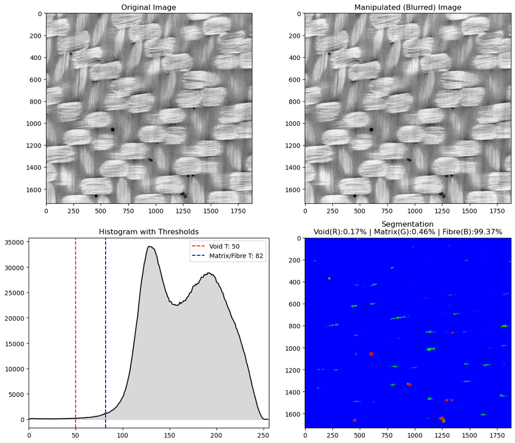

```
Results:
Void Content:   0.17%
Matrix Content: 0.46%
Fibre Content:  99.37%
Threshold used for Matrix/Fibre split: 82
```

```
99.36924321201617
```

```python
from scipy.signal import find_peaks

def analyze_fibre_matrix_content(image_path):
    img = cv2.imread(image_path, 0)
    img_blurred = cv2.GaussianBlur(img, (5, 5), 0)

    # split matrix and fibre by finding threshold
    # histogram plot
    hist = cv2.calcHist([img_blurred], [0], None, [256], [0, 256])
    hist_vals = hist.ravel()

    # look for peaks in the range 50 to 255 since voids known
    search_range_start = 50
    subset_hist = hist_vals[search_range_start:]

    #Find peaks
    peaks, _ = find_peaks(subset_hist, distance=30, height=1000)
    peaks = peaks + search_range_start # Adjust index back to original scale

    if len(peaks) >= 2:
        peak1 = peaks[0]
        peak2 = peaks[1]
        valley_region = hist_vals[peak1:peak2]
        min_idx = np.argmin(valley_region)
        matrix_fibre_threshold = peak1 + min_idx
    else:
        matrix_fibre_threshold = 160

    void_threshold = 50
    total_pixels = img_blurred.size

    # Count pixels based on thresholds
    void_pixels = np.count_nonzero(img_blurred < void_threshold)
    matrix_pixels = np.count_nonzero((img_blurred >= void_threshold) & (img_blurred < matrix_fibre_threshold))
    fibre_pixels = np.count_nonzero(img_blurred >= matrix_fibre_threshold)

    # Calculate Fractions
    vf = (fibre_pixels / total_pixels) * 100
    vm = (matrix_pixels / total_pixels) * 100
    vv = (void_pixels / total_pixels) * 100

    fig, ax = plt.subplots(2, 2, figsize=(12, 10))

    # Original
    ax[0,0].imshow(img, cmap='gray')
    ax[0,0].set_title('Original Image')

    # Blurred
    ax[0,1].imshow(img_blurred, cmap='gray')
    ax[0,1].set_title('Manipulated (Blurred) Image')

    # Histogram
    ax[1,0].plot(hist_vals, color='black')
    ax[1,0].fill_between(range(256), hist_vals, color='gray', alpha=0.3)
    ax[1,0].axvline(void_threshold, color='red', linestyle='--', label=f'Void T: {void_threshold}')
    ax[1,0].axvline(matrix_fibre_threshold, color='blue', linestyle='--', label=f'Matrix/Fibre T: {matrix_fibre_threshold}')
    ax[1,0].set_title('Histogram with Thresholds')
    ax[1,0].set_xlim([0, 256])
    ax[1,0].legend()

    seg_map = np.zeros((img.shape[0], img.shape[1], 3), dtype=np.uint8)
    # Voids in red
    seg_map[img_blurred < void_threshold] = [255, 0, 0]
    # Matrix in green
    seg_map[(img_blurred >= void_threshold) & (img_blurred < matrix_fibre_threshold)] = [0, 255, 0]
    # Fibres in blue
    seg_map[img_blurred >= matrix_fibre_threshold] = [0, 0, 255]

    ax[1,1].imshow(seg_map)
    ax[1,1].set_title(f'Segmentation\nVoid(R):{vv:.2f}% | Matrix(G):{vm:.2f}% | Fibre(B):{vf:.2f}%')

    plt.tight_layout()
    plt.show()

    print(f"Results:")
    print(f"Void Content:   {vv:.2f}%")
    print(f"Matrix Content: {vm:.2f}%")
    print(f"Fibre Content:  {vf:.2f}%")
    print(f"Threshold used for Matrix/Fibre split: {matrix_fibre_threshold}")

    return vf

analyze_fibre_matrix_content('slice_0130.jpeg')
```

Comment: First, three phases of the material are identified, with their threshold values also stated. They are: voids: < 50, matrix and fibre threshold values to be determined from the histogram peaks. The image is first manipulated by Gaussian blur, which is used to smooth an image by applying a Gaussian function, which acts as a nonuniform low-pass filter that reduces noise and negligible details while preserving low spatial frequency. Now the code is first ran with a random parameter to first plot the histogram. Based on this we can find the two peaks which constitute the bulk of the material which is matrix and fibres. The voids are already determined previously based on visual inspection and tweaking the code. Then using the valley of the histogram obtained above we can determine the threshold value now seperating the matrix and fibre content. This value is plugged into the function again as shown below and re-run to produce the actual results.

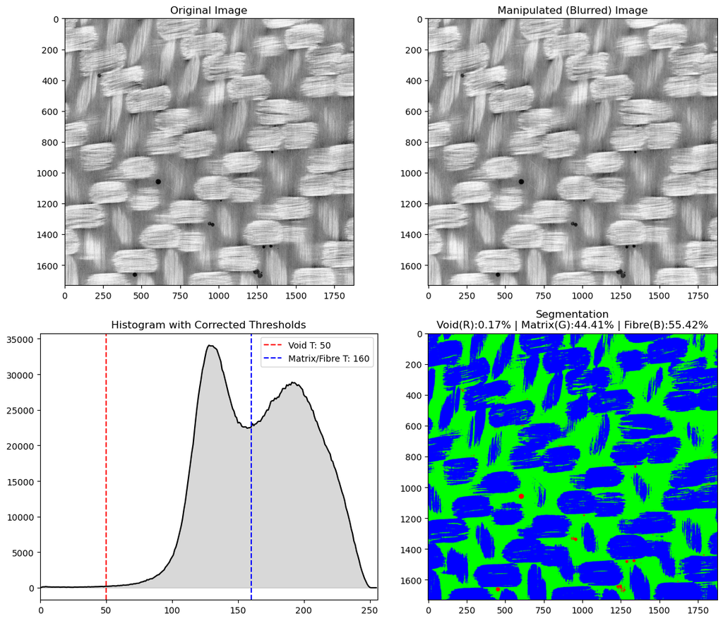

```
Corrected results
Void Content:   0.17%
Matrix Content: 44.41%
Fibre Content:  55.42%
Thresholds used: < 50 (Void), 50-160 (Matrix), > 160 (Fibre)
```

```python
def analyze_fibre_matrix_content_corrected(image_path):
    img = cv2.imread(image_path, 0)
    img_blurred = cv2.GaussianBlur(img, (5, 5), 0)

    # Define thresholds
    void_threshold = 50
    matrix_fibre_threshold = 160

    total_pixels = img_blurred.size

    # Voids: Darkest (< 50)
    void_pixels = np.count_nonzero(img_blurred < void_threshold)

    # Matrix: Mid-range (50 to 160)
    matrix_pixels = np.count_nonzero((img_blurred >= void_threshold) & (img_blurred < matrix_fibre_threshold))

    # Fibres: Brightest (> 160)
    fibre_pixels = np.count_nonzero(img_blurred >= matrix_fibre_threshold)

    # Calculate Fractions
    vv = (void_pixels / total_pixels) * 100
    vm = (matrix_pixels / total_pixels) * 100
    vf = (fibre_pixels / total_pixels) * 100

    fig, ax = plt.subplots(2, 2, figsize=(12, 10))
    # Original
    ax[0,0].imshow(img, cmap='gray')
    ax[0,0].set_title('Original Image')

    # Blurred
    ax[0,1].imshow(img_blurred, cmap='gray')
    ax[0,1].set_title('Manipulated (Blurred) Image')

    # Histogram
    hist_vals = cv2.calcHist([img_blurred], [0], None, [256], [0, 256]).ravel()
    ax[1,0].plot(hist_vals, color='black')
    ax[1,0].fill_between(range(256), hist_vals, color='gray', alpha=0.3)
    ax[1,0].axvline(void_threshold, color='red', linestyle='--', label=f'Void T: {void_threshold}')
    ax[1,0].axvline(matrix_fibre_threshold, color='blue', linestyle='--', label=f'Matrix/Fibre T: {matrix_fibre_threshold}')
    ax[1,0].set_title('Histogram with Corrected Thresholds')
    ax[1,0].set_xlim([0, 256])
    ax[1,0].legend()

    # Segmentation Map
    # Red=Void, Green=Matrix, Blue=Fibre
    seg_map = np.zeros((img.shape[0], img.shape[1], 3), dtype=np.uint8)
    seg_map[img_blurred < void_threshold] = [255, 0, 0]        # Red
    seg_map[(img_blurred >= void_threshold) & (img_blurred < matrix_fibre_threshold)] = [0, 255, 0] # Green
    seg_map[img_blurred >= matrix_fibre_threshold] = [0, 0, 255] # Blue

    ax[1,1].imshow(seg_map)
    ax[1,1].set_title(f'Segmentation\nVoid(R):{vv:.2f}% | Matrix(G):{vm:.2f}% | Fibre(B):{vf:.2f}%')

    plt.tight_layout()
    plt.show()

    print(f"Corrected results")
    print(f"Void Content:   {vv:.2f}%")
    print(f"Matrix Content: {vm:.2f}%")
    print(f"Fibre Content:  {vf:.2f}%")
    print(f"Thresholds used: < {void_threshold} (Void), {void_threshold}-{matrix_fibre_threshold} (Matrix), > {matrix_fibre_threshold} (Fibre)")

analyze_fibre_matrix_content_corrected('slice_0130.jpeg')
```

### Question 7 (4 points)

#### As you have seen in the case study above, defects in composites have the potential to lead to significant consequences. In the next question, you will analyze two Force-Strain datasets for two similar samples. The samples are joined through continuous ultrasonic welding. Their cross-sectional micrographs are displayed below, and can be seen in Figure 9 and 10 respectively.

[figure not shown]

Figure 9

[figure not shown]

Figure 10

#### Question 7.1: Examine Figure 9 and 10. One of these images shows a consolidated sample, the other one shows a defective sample. Please explain which figure belongs to which sample. Also provide a small discussion on the expected differences, and why these differences would occur.

Answer: Figure 9 is the consolidated sample, and Figure 10 is the defective sample. For Figure 9, there is a thin, uniform bond line at the interface between the two laminates that is relatively continuous. There should be no large dark spots (voids). This indicates that the ultrasonic welding parameters like time, energy and pressure were optimised. The vibrational energy generated sufficient friction heat to fully melt the thermoplastic resin. The pressure was adequate to make the molten material flow, filling all gaps and allowing polymer chains to diffuse across the interface, creating a homogeneous joint.

For Figure 10, the image shows distinct defects at the interface. There are black voids causing a visible gap separating the two layers. This porosity is typically caused by insufficient energy input (undercure) or insufficient time. The resin did not reach a high enough temperature to flow and fill the cavity, or the pressure was too low to compact the joint before the resin solidifies. These voids act as stress concentrators, which explains why the defective sample failed so abruptly and at a much lower force in the analysis below. The presence of voids generally increases the rate and amount of moisture absorption in a humid environment, which may cause reduction in matrix-dominated properties. In some composite parts, moisture absorption may result in swelling and changes in part dimensions.

#### Question 7.2: Attached are two datasets of Single Lap Shear tests, both with identical test settings. Each dataset contains the results of 5 samples. One of the datasets is derived from a reasonably well consolidated sample, while the other dataset coming from a defective sample. Plot and analyze the Stress-Strain graphs. Conclude which of the sets is of the defective sample, and explain the difference in plotted curves.

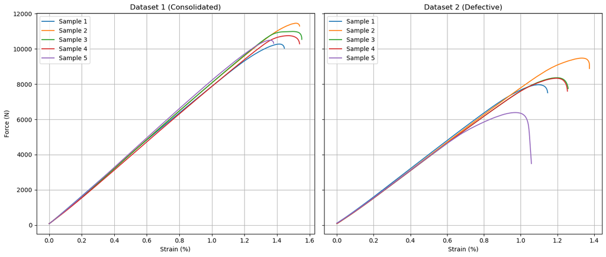

```python
base_dir = r"C:\Users\User\OneDrive - Delft University of Technology\Master Y1\Polymer Composite Manufacturing\Notebook 4 git\PCM-notebooks"

file_path_1 = os.path.join(base_dir, "Weld1Cons.xlsx")
file_path_2 = os.path.join(base_dir, "Weld2Cons.xlsx")

df1 = pd.read_excel(file_path_1, header=None)
df2 = pd.read_excel(file_path_2, header=None)


fig, (ax1, ax2) = plt.subplots(1, 2, figsize=(14, 6), sharey=True)

for i in range(0, 10, 2):
    ax1.plot(df1[i], df1[i+1], label=f'Sample {i//2 + 1}')

ax1.set_title('Dataset 1 (Consolidated)')
ax1.set_xlabel('Strain (%)')
ax1.set_ylabel('Force (N)')
ax1.legend()
ax1.grid(True)

for i in range(0, 10, 2):
    ax2.plot(df2[i], df2[i+1], label=f'Sample {i//2 + 1}')

ax2.set_title('Dataset 2 (Defective)')
ax2.set_xlabel('Strain (%)')
ax2.grid(True)
ax2.legend()

plt.tight_layout()
plt.show()
```

Comment: Based on the analysis of the provided datasets, the stress-strain behavior has been plotted below. Dataset 1 (Weld1Cons) is the consolidated sample. This dataset shows a higher peak force which is more than 10000 N and fails at a higher strain level generally more than 1.4%. The curves are consistent and show a cleaner transition to failure, indicating a strong bond. Dataset 2 (Weld2Cons) is the defective sample. This dataset shows a significantly lower peak force at less than 10000N and premature failure at lower strain levels less than 1.4%. This reduced strength is the direct result of the defects such voids or lack of fusion acting as stress concentrators and reducing the effective bonded area. The consolidated samples (Dataset 1) sustain load much longer, indicating a tough, ductile response where the weld holds until the bulk material or a large shear area yields. The defective samples (Dataset 2) fail abruptly at lower loads such as in sample 5, like that of brittle fracture where a crack propagates rapidly through the existing voids in the weak bond line.

#### Question 7.3: From your results of Q7.2, you should be able to derive that the elastic moduli are approximately similar for all samples. Explain why this is the case.

Answer: Despite the significant difference in failure load, the elastic modulus which is the slope of the initial linear portion of the curve is approximately similar for both the consolidated and defective samples. Modulus is a bulk property. In a Single Lap Shear test, the stiffness (slope) is still dominated by the bulk material properties of the composite plates and the overlap geometry. Since both samples use the same base composite material, their resistance to elastic deformation is identical. Defects affect the ultimate strength, not stiffness. The defects are localised at the interface. Even though they drastically reduce the maximum load the joint can carry before snapping, they do not significantly alter the overall stiffness of the assembly while it is still intact. The elastic moduli of the system remains effectively the same until the weak bond begins to fail.